# Taller_1 Simulacion

Santiago Sabogal - Pablo Emilio Muñoz

2022-03-11

# Tamaño de machos y hembras de langostinos

Al comparar los caracteres morfométricos de una especie de langostinos de gran importancia económica en Argentina se observaron diferencias de tamaño entre macho y hembra. En la siguiente tabla se presentan los datos (Largo total mm) de las morfometrías de machos y hembras obtenidos en diferentes recolectas (Ruiz & Mendia, 2008).

### Tabla 1. Morfometrías de machos y hembras

| Hembras | Machos |
| --- | --- |
| 183.2, 182.5, 166.8,184.1, 190.0, 196.3, 183.0, 178.1, 193.3, 204.3, 193.2, 187.3, 176.5, 180.4, 185.8, 179.0, 184.3, 189.3, 188.3, 189.2, 195.5, 186.8, 189.1, 202.4, 202.2, 203.1, 210.8 | 140.9, 173.9, 118.9, 121.7, 177.4, 140.0, 173.8, 154.8, 192.7, 154.5, 177.5, 134.4, 109.2, 153.4, 175.0, 150.7, 138.7, 169.8, 203.3, 136.7, 153.9, 163.0, 165.3, 176.7,137.7, 126.7, 150.0 |

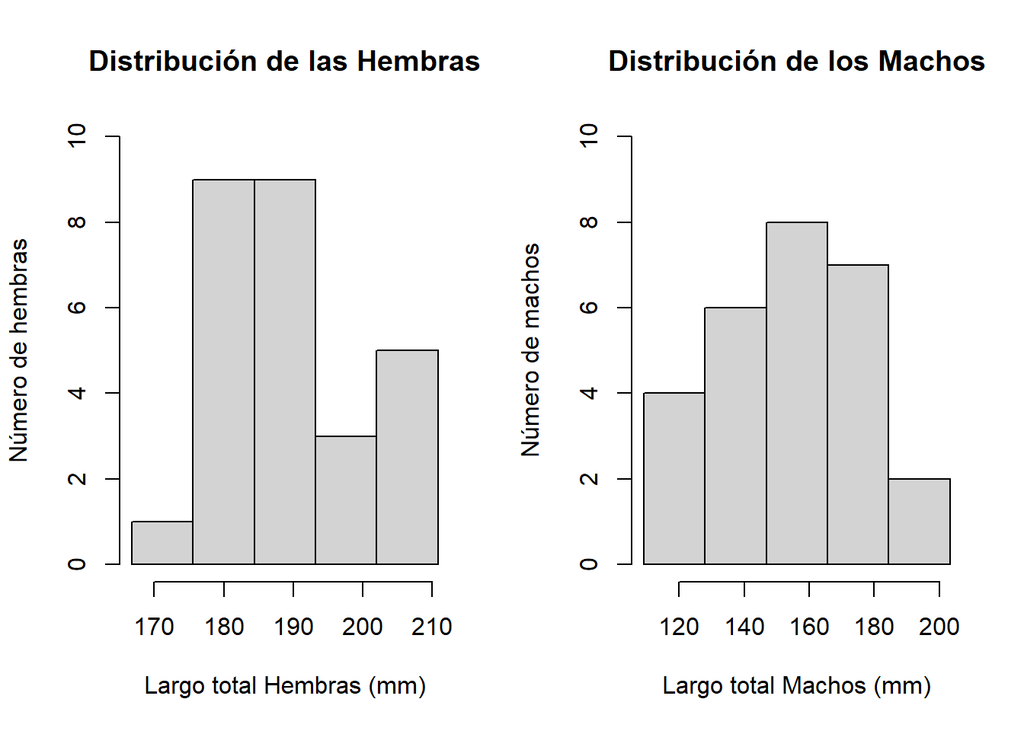

#### Cálculos langostinos hembras

```
##
##  One Sample t-test
##
## data:  hembras
## t = 0, df = 26, p-value = 1
## alternative hypothesis: true mean is not equal to 189.0667
## 97 percent confidence interval:
##  184.7230 193.4104
## sample estimates:
## mean of x
##  189.0667
```

#### Cálculos langostinos machos

```
##
##  One Sample t-test
##
## data:  machos
## t = 0, df = 26, p-value = 1
## alternative hypothesis: true mean is not equal to 154.4667
## 97 percent confidence interval:
##  144.2760 164.6573
## sample estimates:
## mean of x
##  154.4667
```

### Análisis

**Gráficas:** De acuerdo con la distribución que presenta el grafico de las *hembras*, se puede observar que los datos se distribuyen con una asimetría Negativa, el cual se interpreta como datos cargados a la derecha con cola hacia la izquierda, además, el grado de concentración que presentan los valores se clasifica como una distribución leptocúrtica con una concentración de los datos en el rango entre 175 mm y 192 mm. Con respecto al grafico de los *machos*, se observa una asimetría positiva con cola a la derecha y un grado de concentración mesocúrtica.

**Variabilidad :** Con base en la desviación estandar obtenida tanto para las hembras como para los machos de langostino, se puede concluir que la desviación del tamaño de las hembras con respecto su media de 189.0667 mm equivale a 9.8311 mm en promedio y la desviación del tamaño de los machos con respecto su media de 154.4667 mm equivale a 23.0646 mm en promedio, lo cual significa que los machos tienen una mayor variación en sus dimensiones de tamaño.

**Intervalos con nivel de confianza:**

• Con base en un nivel de confianza del 97% se ha obtenido un intervalo para las hembras entre [ 184.7230 - 193.4104 ]

• Con base en un nivel de confianza del 97% se ha obtenido un intervalo para los machos entre [ 144.2760 - 164.6573 ]

En ambos casos, se aprecia una precision de las medidas efectuadas y en la estabilidad de los valores estimados llegado el caso de repetirse el experimento o al aumentar la muestra.

### Boxplort por sexo

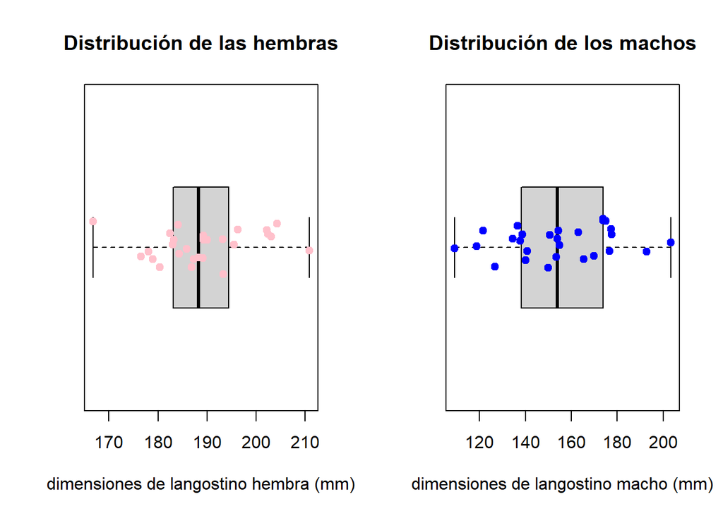

### Análisis

**Mediana:** La mediana se identifica como la linea negra mas gruesa que esta dentro de la caja, para el caso de las hembras la mediana es igual a *188.3* y para los machos es de *153.9*

**Cuatiles :** Como en el diagrama se muestran el valor que delimita desde el primer 25% de la muestra (Q1, límite inferior de la caja) hasta el 75% de la muestra (Q3, límite superior de la caja), la caja completa delimita las puntuaciones centrales de la variable. Es decir, la caja representa el 50 % central de las puntuaciones de una variable, sin el 25% más pequeño y el 25% más alto.

• En el diagrama de las hembras, el valor de Q1 es 183.1, y el valor de Q3 es 194.4 Esto quiere decir que el 50% central de la variable oscila entre las puntuaciones 183.1 mm y 194.4 mm.

• En el diagrama de los machos, el valor de Q1 es 138.20, y el valor de Q3 es 173.85 Esto quiere decir que el 50% central de la variable oscila entre las puntuaciones 138.20 mm y 173.85 mm.

### Coeficiente de variación

| Hembras | Machos |
| --- | --- |
| 5.19% | 14.93% |

### Análisis

Con respecto a la dispersión relativa, la variación de tamaño de los machos es mayor con un 9.74% más con respecto a las hembras.

### Comprobación de Normalidad

Como la muestra es de 27 datos, en este caso *n < 50*, se debe aplicar la prueba de normalidad de *Shapiro-Wilks*

| p-value hembras | p-value en machos |
| --- | --- |
| 0.7606 | 0.8935 |

### Análisis

Con respecto al test de *Shapiro-wilks* se ha obtenido que para un nivel de confianza del 95%, como el *p-value* de en ambos casos sobrepasa el *alpha* de 0.05, por lo tanto, no se tiene evidencia suficiente para rechazar la hipotesis nula, lo que significa que tanto para hembras como para machos la distribución es normal.

# Probabilidad para billetes de $50.000 en un restaurante

En un restaurante de la ciudad se sabe que la probabilidad de que se reciba un billete de $50.000 falso es de 0.015. Si se sabe que en una semana se reciben pagos con 900 billetes de $50.000:

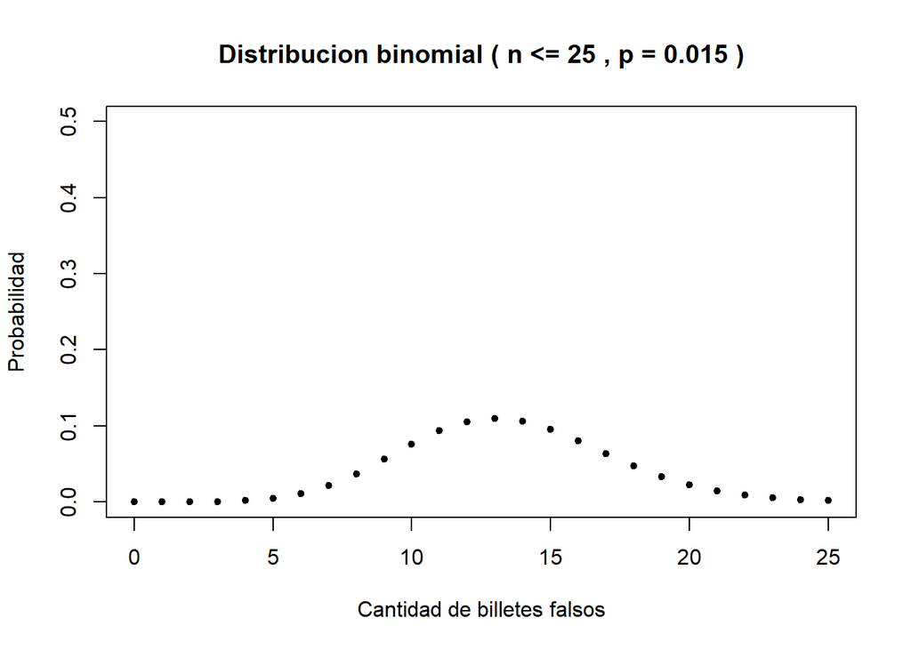

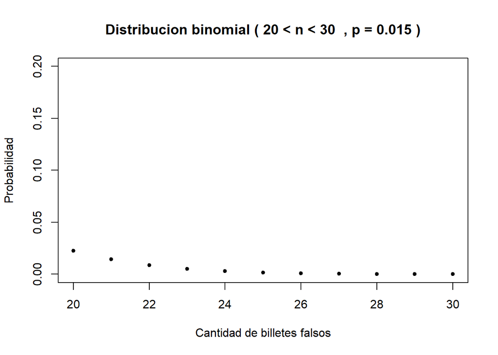

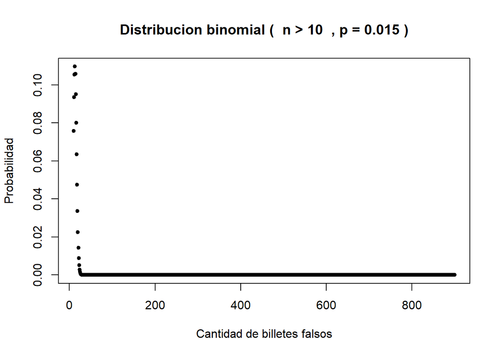

# Vida media para una población de 100.000 habitantes

Según un estudio del Departamento Nacional de Estadística -DANE-, la vida media para el quinquenio de 2010 a 2015 de los habitantes de Colombia es 76 años, con una varianza de 25. Se pretende hacer un estudio con el objetivo de extrapolar los resultados anteriores a una pequeña ciudad de 100.000 habitantes, considerando que el tiempo de sobrevida es normal.

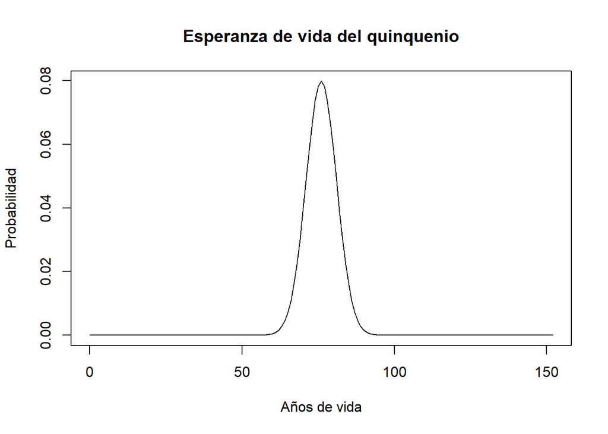

¿Cuántos de los habitantes de la pequeña ciudad superarán previsiblemente los 92 años?

```
## [1] 68.71379
```

De los 100.000 habitantes de la pequeña cuidad, se calcula que 68 habitantes podrán superar los 92 años de vida.

¿Cuántos vivirán menos de 55 años o más de 75 años?

```
## [1] 57922.8
```

De los 100.000 de la pequeña cuidad, 57.922 habitantes pueden vivir menos de 55 años y más de 75 años.